# Analysis of PHB sorting of a N-rich transposon library

Arvid Gynnå & Michael Jahn

29 September, 2021

## Description

This R notebook is a bioinformatics pipeline to analyze data obtained by sorting a barcoded transposon library in *Ralstonia eutropha* (a.k.a. *Cupriavidus necator*) by density, achieving a selection by PHB content. For background and details regarding the method, see [Wetmore at al., mBio, 2015](https://mbio.asm.org/content/6/3/e00306-15) and [Price et al., Nature, 2018](http://www.nature.com/articles/s41586-018-0124-0)). This notebook has been adapted from a pipeline for analysis of chemostat competition experiments by Michael Jahn.

The dataset is a NextSeq 500 run, from two experiments with PHB sorting by centrifuge with either abundant or no nitrogen (NH4Cl). A problem (see below) was that the diversity in the libraries was much worse than we had seen before, especially in the N-starved sample. For this reason, the N-starvation experiment was redone (see another notebook) and only the N-rich condition was used.

## Overview of barcode/transposon read counts

### Data import and processing

Read in the main data tables with A) reads per barcode and sample (‘pool counts’), B) the fitness tables, C) the summary statistics, and D) the genome annotation. Tables were obtained by processing sequencing data with a custom [BarSeq pipeline](https://github.com/m-jahn/rebar).

### Get gene annotation and esssentiality

## Summary statistics

Overview about the number of reads per sample and their mapping. The proportion of mapped reads is lower than normal (~75 %) in all samples. While N+ samples and N- no 3 have ca 35 % mapped reads (already low), the remaining N- are around 9%. Notably N+ and N- no 3 was done in a different experiment compared to the remaining N- samples, with a different pre-cultures inoculated at different days. This suggest the low mapping was caused by the experiment, rather than during sequencing.

Manual inspection of the reads show that the vast majority of the reads have normal read structure, i. e. the presequence, a 20-nt barcode and the post-sequence. The problem is that the barcode could not be mapped to a known barcode from the TnSeq. Let’s inspect the actual barcodes we got…

```
Expected 4 pieces. Additional pieces discarded in 48 rows [1, 2, 3, 4, 5, 6, 7, 8, 9, 10, 11, 12, 13, 14, 15, 16, 17, 18, 19, 20, ...].
```

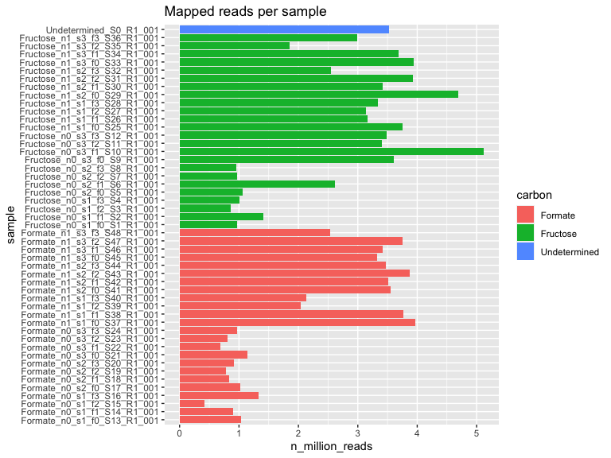

```
Expected 5 pieces. Additional pieces discarded in 48 rows [1, 2, 3, 4, 5, 6, 7, 8, 9, 10, 11, 12, 13, 14, 15, 16, 17, 18, 19, 20, ...].
```

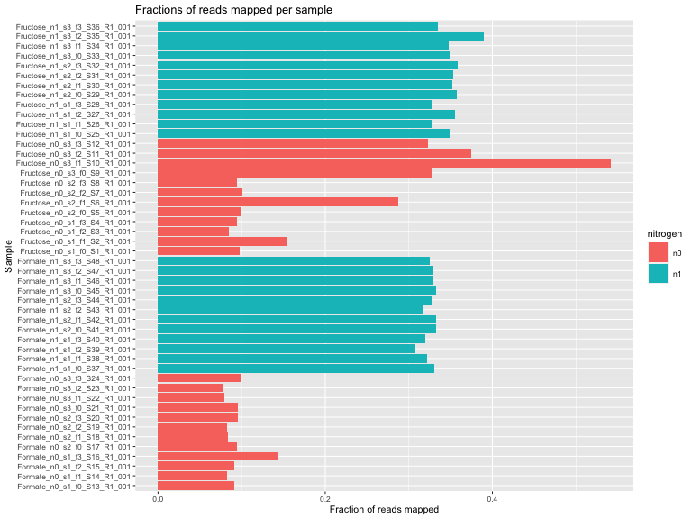

### Barcode diversity

To investigate the barcode distribution, we compare samples from the low- and high-mapping samples to a sample from the previous sucrose-formate MC experiment. Here we used unsorted F0 samples, that should not have been enriched for PHB-related mutants.

Based on this, there could be said to be two separate problems.

- Extreme enrichment of a few barcodes, leading to read compression
- General enrichment of un-mappable barcodes

Michael has inspected some of the un-mapped barcodes manually. He found both those that were not seen by the TnSeq data at all, and those that were seen but mapped to several locations (likely due to short read length). This means that the un-mapped codes are likely real strains in the Tn library, but that a small group of mutants have been overly enriched.

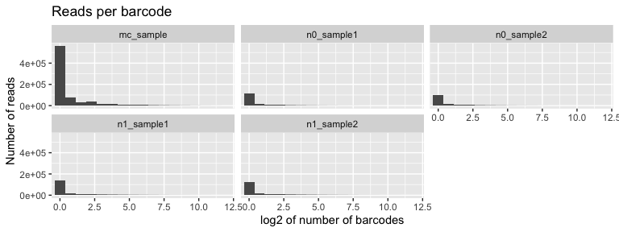

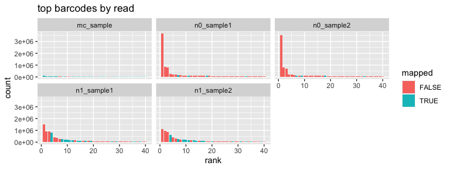

| sample | total_barcodes | mapped_barcodes |
| --- | --- | --- |
| mc_sample | 776124 | 49965 |
| n0_sample1 | 153017 | 12229 |
| n0_sample2 | 139780 | 15592 |
| n1_sample1 | 197074 | 11660 |
| n1_sample2 | 180136 | 13291 |

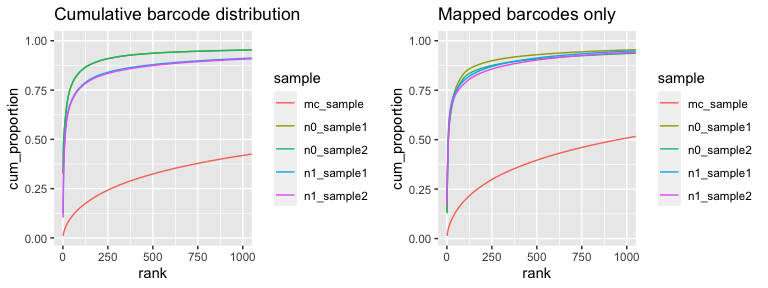

Which are these barcodes? Is it the same over-enriched and unmappable barcodes between the samples, and between the experiments?

Here we plot the the common genes among the 200 most seen BarSeq mutants in two experiments. We see that the in the two N-starved replicates, the reads are almost identical. In the N-rich samples, the read numbers are highly correlated **but** about half the mutants are about 30 % more prevalent in one of the samples. The reason for this is unknown.

Between the N-starved and N-rich samples, we also see that it is largely the same mutants that are enriched. Between the new samples and the old sample however, there were only few mutants that appeared together.

The conclusion is that the enrichment of these mutants depends on some common factor between the two different experiments performed before centrifuge sorting, but that these factors were not present in the MC experiment. The cause of these problems is likely somewhere in the experiment, not in the seq library preparation or in the sequencing. Two theories are

- Repeated freeze-thaw cycles of the frozen library has biased the survivors.
- The preculture phases have selected has biased the library

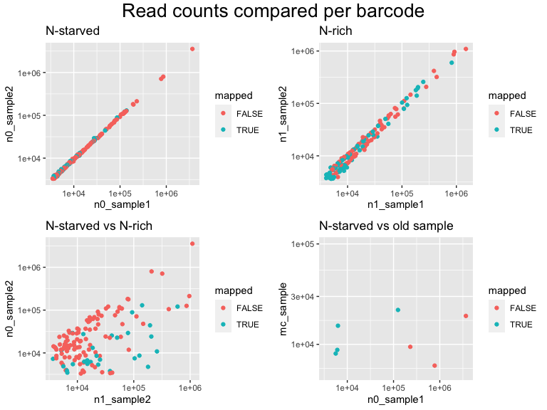

Distribution of **number of reads per barcode**. Many samples have less than few barcodes with more than 2^5 = 32 barcodes, will be hard to quantify these. Blue is the mean in each sample.

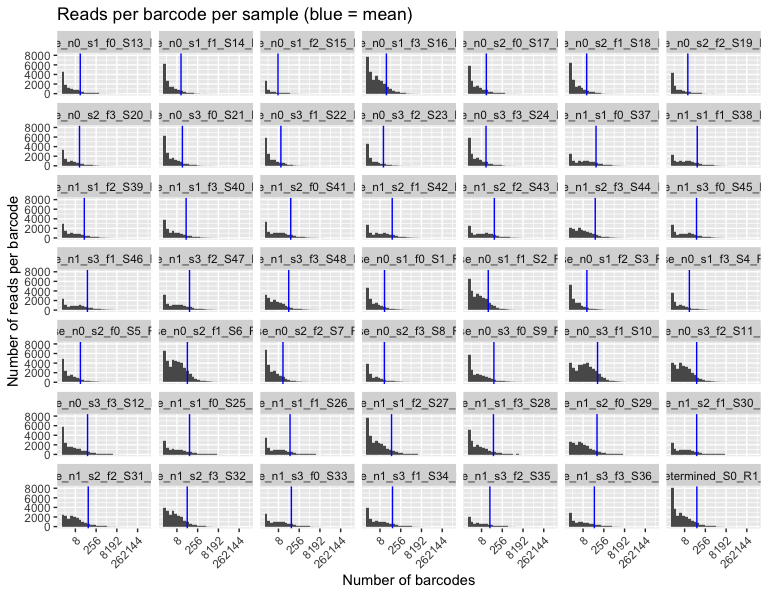

Similarly to the above, this is an overview about the **number of barcodes per gene** as a histogram. This distribution is the same for all conditions and replicates. The second plot is the **number of reads per gene**, averaged as median over all conditions (excluding 0 time point where counts were averaged by BarSeq pipeline).

The average of detected barcodes per gene is 3.8, and the median is 3. The average reads per gene is 384, and the median is 15.5.

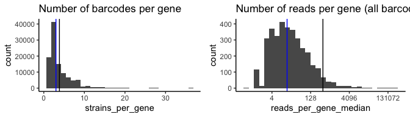

There are somewhat more reads per gene if we include only the N-rich samples. The average of detected barcodes per gene is 3.7, and the median is 3. The average reads per gene is 499, and the median is 18.

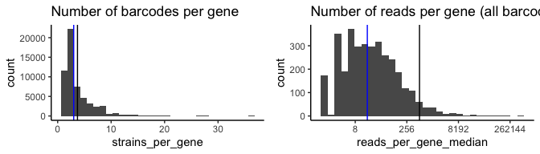

## Gene fitness analysis

We can plot log2 FC or normalized gene fitness over generations. For this type of overview it is best to summarize individual replicates (3x) to the mean or median, per time point and condition. We also add genome annotation to the summary table.

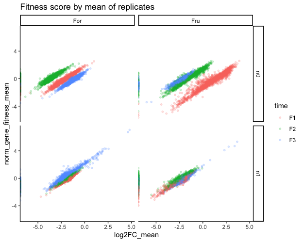

### Most enriched dense mutants in N-rich conditions

Cells producing PHB become denser, meaning they fall through the density gradient to the middle or bottom fractions (F2 and F3). If look at which strains that are enriched here, i. e. cells producing PHB even when not N-starved, there were several significant hits. Interestingly, the two strongest hits in both conditions are the same and related: leuC and leuB. Otherwise, most of the hits were just present in one medium, and there are more significant scores (>2.5) in the formate condition.

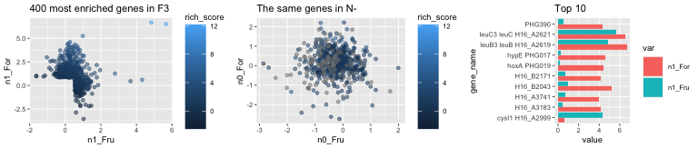

Here are the 60 most F3-enriched genes:

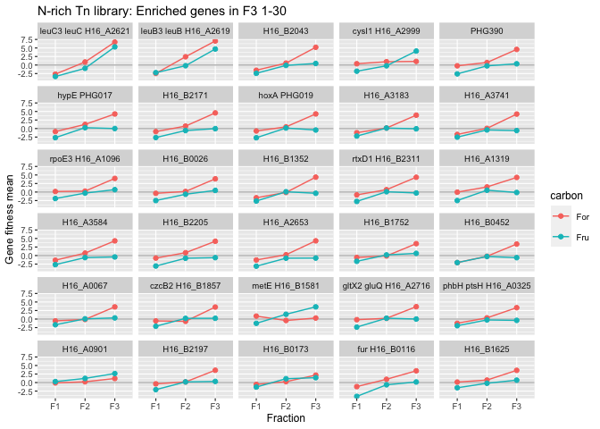

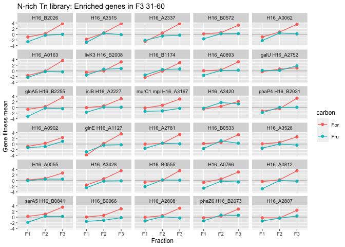

If we only look at non-essential genes:

The lists of fructose- and formate-essential genes are identical in this case. The 8-generation score from the M experiments is plotted in each subpanel.

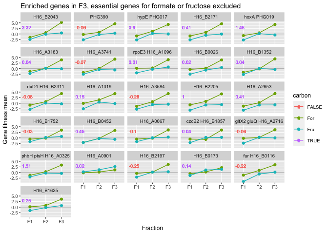

### Most depleted light cells

When N is abundant, wt cell produce little PHB and normaly band in the top fraction after centrifugation. What should be equivalent is to select mutants depleted in the F1 fraction. The leuBC genes are seen here as well.

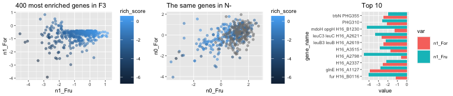

Here are the 60 most F1-depleted genes:

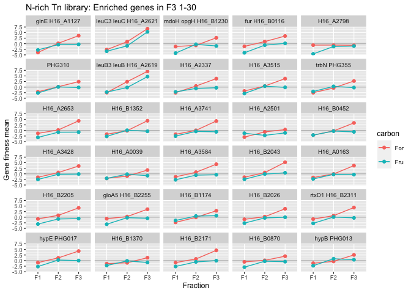

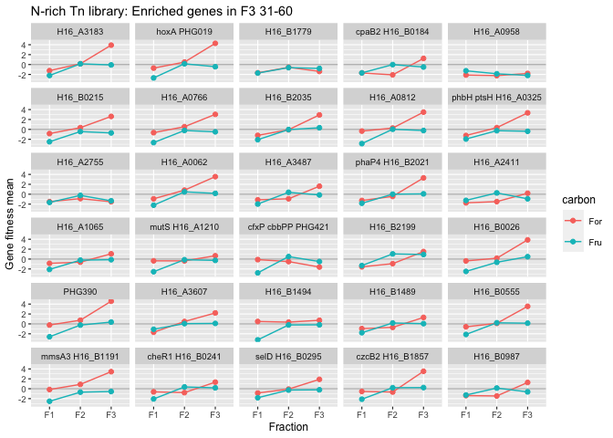

If we only look at non-essential genes: The fructose- and formate-essential genes are identical also here. The 8-generation score from the MC is plotted in each subpanel.

[figure not shown]

### Protein interactions

To learn more about functional relationships between enriched genes/mutants, we can submit the gene list to the STRING interaction database and retrieve a network of probable interactions. Copied from Micheals BarSeq-pulse.

Get the most enriched genes and submit to STRING.

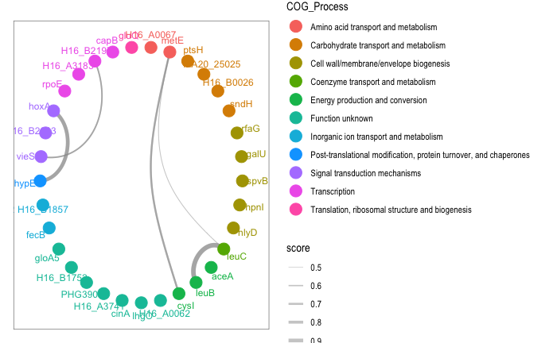

### Leucine biosynthesis

There is enrichment of some leucine synthesis genes in N-rich sinking cells. If we display all leucine synthesis genes, we see that only leuB, leuC and leuD are affected. They are depleted in floating cells and enriched in sinking cells. There is a such trend also in N-starvation conditions. None of these genes are obviously related to PHB synthesis.

| locus_tag | gene_name | Process | Pathway |
| --- | --- | --- | --- |
| H16_A0477 | leuB1 H16_A0477 | Carbohydrate metabolism | Glyoxylate and dicarboxylate metabolism |
| H16_A0561 | ilvE H16_A0561 | Amino acid metabolism | Cysteine and methionine metabolism |
| H16_A1041 | leuA H16_A1041 | Amino acid metabolism | Valine, leucine and isoleucine biosynthesis |
| H16_A1236 | leuC leuC1 H16_A1236 | Amino acid metabolism | Valine, leucine and isoleucine biosynthesis |
| H16_A1237 | leuD leuD1 H16_A1237 | Amino acid metabolism | Valine, leucine and isoleucine biosynthesis |
| H16_A1549 | leuC2 H16_A1549 | Amino acid metabolism | Valine, leucine and isoleucine biosynthesis |
| H16_A2133 | leuB2 H16_A2133 | Carbohydrate metabolism | Glyoxylate and dicarboxylate metabolism |
| H16_A2619 | leuB3 leuB H16_A2619 | Amino acid metabolism | Valine, leucine and isoleucine biosynthesis |
| H16_A2620 | leuD leuD3 H16_A2620 | Amino acid metabolism | Valine, leucine and isoleucine biosynthesis |
| H16_A2621 | leuC3 leuC H16_A2621 | Amino acid metabolism | Valine, leucine and isoleucine biosynthesis |

[output cut: 5 more lines]

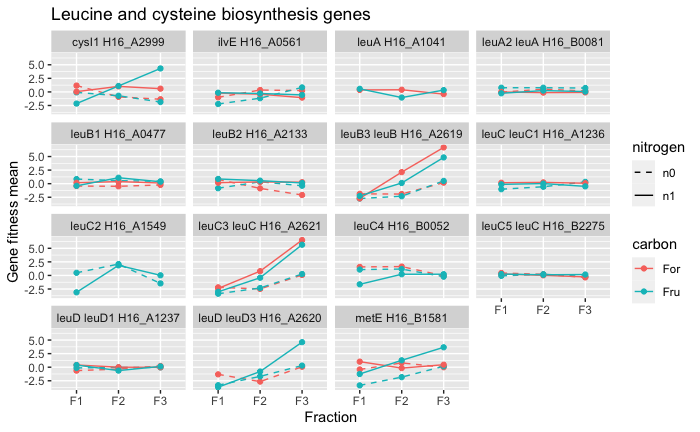

The leuBCD genes share a common operon, with only these three genes. To check whether it could be a wider genomic effect, we can look at the surrounding genes. There is no data for flanking asd gene, but neither of the neighbors on either side fimV or livF show any enrichment or depletion on the gradient.

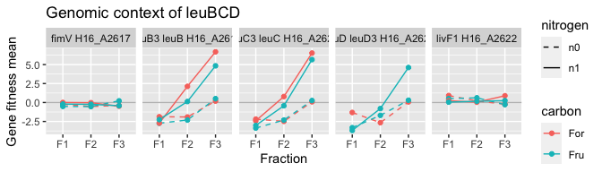

### Hydrogenases

There are several hydrogenases that have a pattern where the in the fructose sample it is depleted in the floating fraction and in the formate sample is enriched in the sinking fraction. These are, to varying degrees, hoxA, hypB, hypE, hypF and the unnamed PHG390.

| locus_tag | gene_name | Process | Pathway |
| --- | --- | --- | --- |
| PHG001 | hoxK PHG001 | Xenobiotics biodegradation and metabolism | Nitrotoluene degradation |
| PHG002 | hoxG PHG002 | Xenobiotics biodegradation and metabolism | Nitrotoluene degradation |
| PHG008 | hoxQ PHG008 | Poorly characterized | General function prediction only |
| PHG012 | hypA PHG012 | Genetic information processing | Chaperones and folding catalysts |
| PHG013 | hypB PHG013 | Genetic information processing | Chaperones and folding catalysts |
| PHG014 | hypF1 hypF PHG014 | Unclassified: genetic information processing | Protein processing |
| PHG015 | hypC PHG015 | Unclassified: genetic information processing | Protein processing |
| PHG016 | hypD PHG016 | Unclassified: genetic information processing | Protein processing |
| PHG017 | hypE PHG017 | Unclassified: genetic information processing | Protein processing |
| PHG018 | hypX PHG018 | Signaling and cellular processes | Two-component system |

[output cut: 5 more lines]

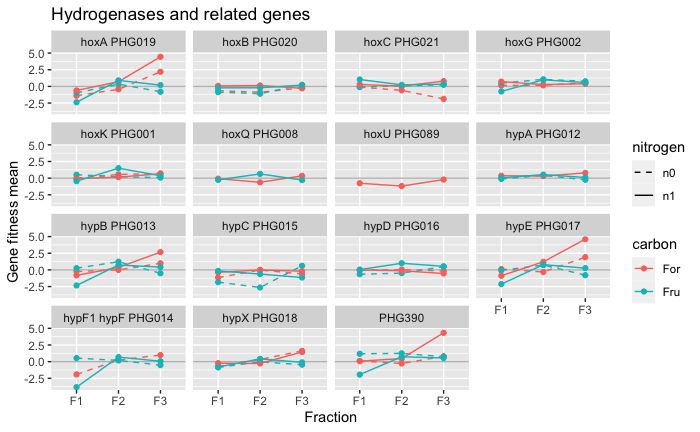

A collection of other, mosty little characterized genes

| locus_tag | gene_name | Process | Pathway |
| --- | --- | --- | --- |
| H16_A3183 | H16_A3183 | Hypothetical | Hypothetical |
| H16_A3741 | H16_A3741 | Hypothetical | Hypothetical |
| H16_B2043 | H16_B2043 | Hypothetical | Hypothetical |
| H16_B2171 | H16_B2171 | Lipid metabolism | Sphingolipid metabolism |
| PHG390 | PHG390 | Hypothetical | Hypothetical |

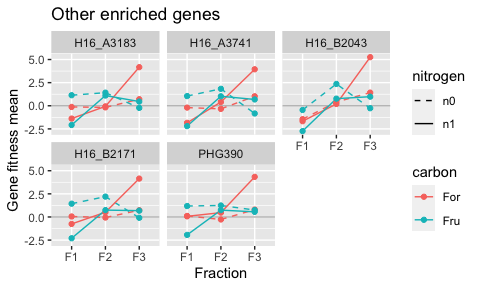